# 회귀선의 계수를 구하는 방법

lec5

hanbyeol true  
04-01-2021

이번 시간에는 회귀선의 계수를 구하는 방법을 이론적으로 풀어보고, 실제로 행렬을 이용해서 구해봤다.

# 1. beta

알고있는 점과 회귀선의 직선거리가 최소가 되게 하는 계수를 beta라고 했을 때 행렬을 이용해서 풀면 다음과 같다.

$$beta = (X^TX)^{-1}X^Ty$$

# 2. mtcars data를 이용해서 직접 구해보기

```r
head(mtcars)
```

```
                   mpg cyl disp  hp drat    wt  qsec vs am gear carb
Mazda RX4         21.0   6  160 110 3.90 2.620 16.46  0  1    4    4
Mazda RX4 Wag     21.0   6  160 110 3.90 2.875 17.02  0  1    4    4
Datsun 710        22.8   4  108  93 3.85 2.320 18.61  1  1    4    1
Hornet 4 Drive    21.4   6  258 110 3.08 3.215 19.44  1  0    3    1
Hornet Sportabout 18.7   8  360 175 3.15 3.440 17.02  0  0    3    2
Valiant           18.1   6  225 105 2.76 3.460 20.22  1  0    3    1
```

## 2.1 X와 y 값 설정

y 값으로는 mpg, **X** 벡터들로는 cyl,disp, hp를 가져온다.

```r
y <- as.vector(mtcars[,1])
X <- as.matrix(mtcars[,2:4])
```

## 2.2 intercept 열 추가

intercept를 추가해주기 위해 cbind()를 이용해서 열을 더해준다.

```r
X <- cbind(1,X)
```

- Transpose: *t(X)*
- 행렬의 곱: %*%
- 역행렬: *solve()*

따라서 우리가 구하고자 하는 식을 행렬로 표현하면

```r
beta <- solve(t(X) %*% X) %*% t(X) %*% y
```

```r
result <- lm(mpg ~ cyl + disp + hp, data=mtcars)
result$coefficients
```

```
(Intercept)         cyl        disp          hp
34.18491917 -1.22741994 -0.01883809 -0.01467933
```

```r
library(tibble)
set.seed(2021)
```

- x: 0에서 1사이에 0.05씩 떨어져 있는 수 중에서 10개를 무작위로 뽑아라

```r
x <- sample(seq(0,1,by=0.05), 10)
```

- y: 그 x를 sin 2pi에 넣고 epsilon(rnorm, sd=0.2인)을 더해라

```r
y <- sin(2* pi * x) + rnorm(length(x), sd=0.2)
```

```r
mydata <- tibble(x = x, y = y)
mydata
```

```
# A tibble: 10 x 2
       x      y
   <dbl>  <dbl>
 1  0.3   1.00
 2  0.25  1.18
 3  0.65 -0.806
 4  1     0.346
 5  0.55 -0.525
 6  0.15  0.754
 7  0.95 -0.273
 8  0.7  -0.649
 9  0.5   0.321
10  0.9  -0.956
```

- 원래 값과 비교

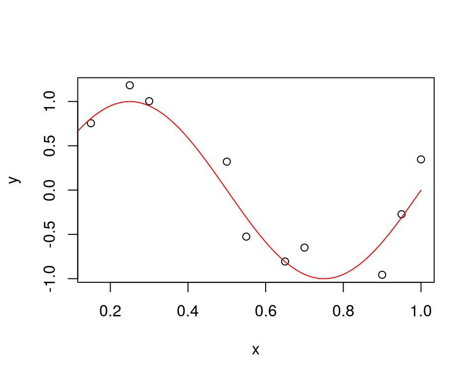

```r
x2 <- seq(0, 1, by = 0.01)
y2 <- sin(2 * pi * x2)
plot(x, y)
points(x2, y2, type="l", col = "red")
```

## 2.4 위 데이터를 다항식을 이용해서 표현하기

- 0차 polynomial

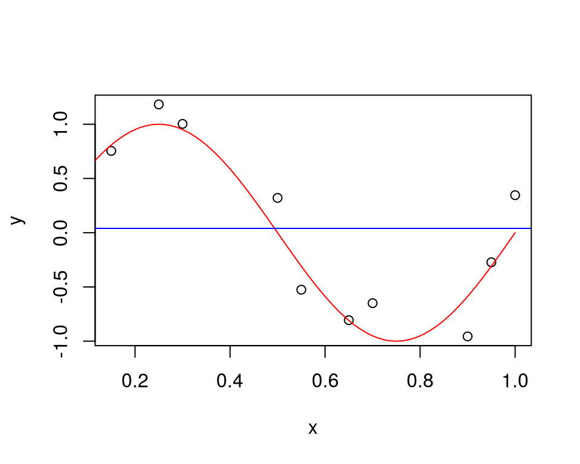

```r
x2 <- seq(0, 1, by = 0.01)
y2 <- sin(2 * pi * x2)
plot(x,y)
points(x2, y2, type="l", col = "red")
abline(h = mean(y), col = "blue")
```

- 1차식으로 회귀직선 구하기

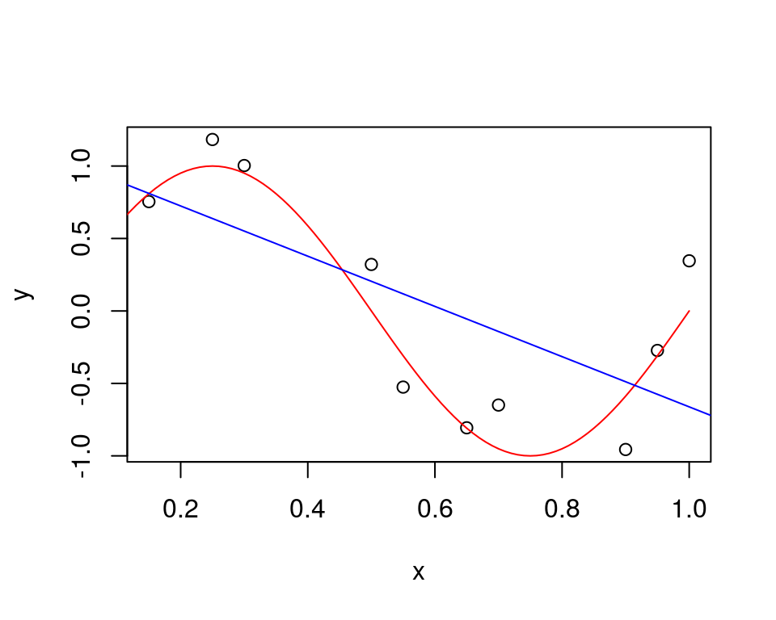

```r
x2 <- seq(0, 1, by = 0.01)
y2 <- sin(2 * pi * x2)
result <- lm(y~x, data = mydata)
plot(x, y)
points(x2, y2, type="l", col = "red")
abline(result, col="blue")
```

- 3차식으로 회귀직선 구하기

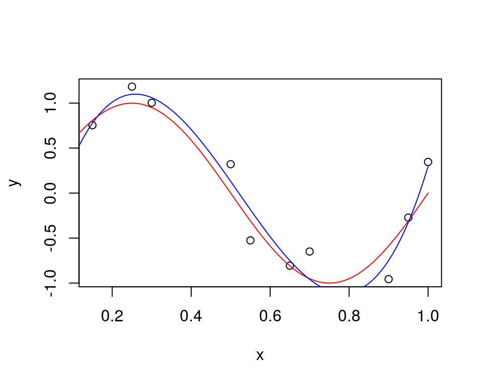

```r
x2 <- seq(0, 1, by = 0.01)
y2 <- sin(2* pi * x2)
result <- lm(y ~ poly(x, 3), data = mydata)
plot(x, y)
points(x2, y2, type ="l", col = "red")
y3 <- predict(result, newdata = tibble(x = x2))
points(x2, y3, type="l", col="blue")
```

# 2.5 행렬을 이용해서 3차 회귀계수방정식, beta구하기

```r
X <- cbind(1, x, x^2, x^3)
beta <- solve(t(X) %*% X) %*% t(X) %*% y
```

- 구한 베타로 예측하는 곡선 그리기

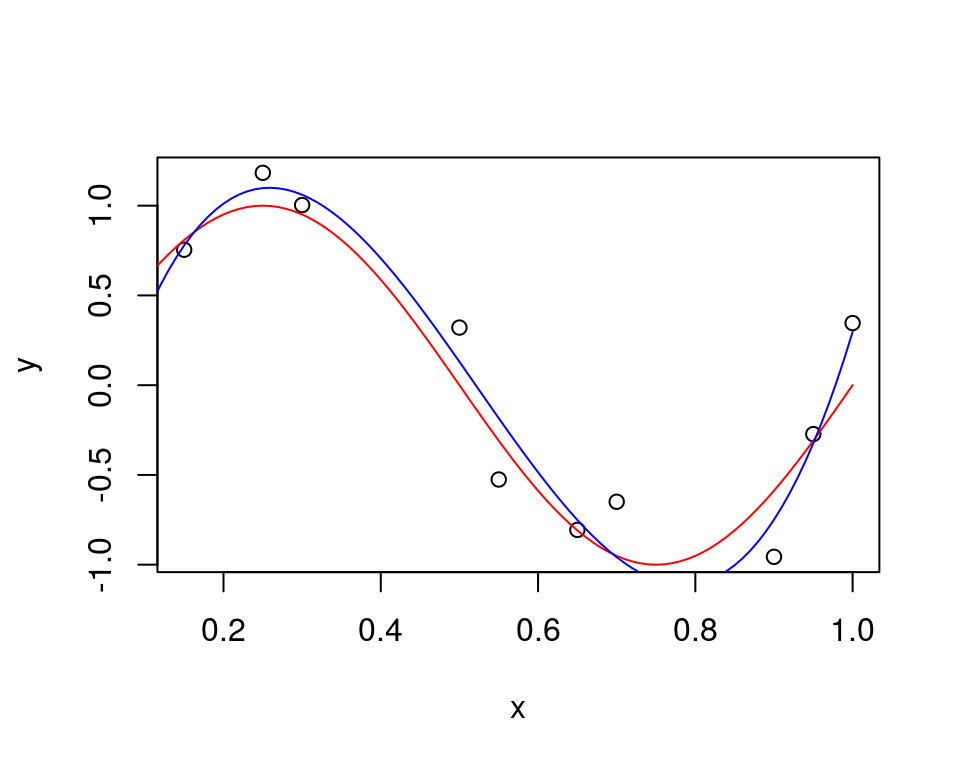

```r
beta <- as.vector(beta)
x3 <- seq(0, 1, by=0.01)

y_hat <- beta[1] + x3 * beta[2] + x3^2 * beta[3] + x3^3 * beta[4]
plot(x,y)
points(x2, y2, type = "l", col = "red")
points(x3, y_hat, type = "l", col = "blue")
```